# Funções de uma variável

22/03/2021

## Problema 1

## Problema 1

Se \(f′\) for uma função contínua, \(f(1)=0\) e \(f′(1)=-5\), calcule \[ \lim_{x\to 3}\frac{f(7- 2x)}{1-\ln (7- 2x)}\nonumber \]

### Solução

- Para \(x=3\), \(f(7-2x)=f(1)=0\) e \(\ln (7-2x)=\ln(1) = 0\)
- Além de \[1-\ln (7-2\cdot3)=1-\ln(1) = 1\]
- Logo \[ \lim_{x\to 3}\frac{f(7- 2x)}{1-\ln (7- 2x)} = \frac{0}{1} = 0\nonumber \]

## Problema 2

## Problema 2

Se \(g′\) for uma função contínua, \(g(1)=0\) e \(g′(1)=2\), calcule \[ \lim_{x\to 0}\frac{g(1-5\sin 2x)g(1+5\sin 2x)}{\sin 2x}\nonumber \]

### Solução

- Como \(g(1)=0\) e \(\sin 0=0\), temos uma indeterminação do tipo \(\frac{0}{0}\).
- Nesse caso podemos usar L’Hôspital.
- Para isso precisamos calcular \[ \frac{d}{dx}\left[g(1-5\sin 2x)g(1+5\sin 2x)\right] \]
- Para isso usaremos a regra da cadeia e a regra do produto
- definindo \(u(x) = \sin 2x\) a derivada do numerador se torna \[ \frac{d}{dx}\left[g(1-5u(x))g(1+5u(x))\right] = \frac{d}{dx}\left[g(1-5u)\right]g(1+5u)+g(1-5u)\frac{d}{dx}\left[g(1+5u)\right] \]
- Calcular essa derivada fica mais simples definindo \(u_1 = 1-5u\) e \(u_2 = 1+5u\)
- O que resulta em \[ \begin{align} \frac{d}{dx}\left[g(u_1)g(u_2)\right] &= \frac{d}{dx}\left[g(u_1)\right]g(u_2)+g(u_1)\frac{d}{dx}\left[g(u_2)\right]\\ & = \left[\frac{dg(u_1)}{du_1}\frac{du_1}{dx}\right]g(u_2)+g(u_1)\left[\frac{dg(u_2)}{du_2}\frac{du_2}{dx}\right]\\ \end{align} \]
- usando \(u'(x) = 2\cos 2x\), (verifique!) \[ \begin{align} \frac{d}{dx}\left[g(u_1)g(u_2)\right]& = \left[g'(u_1)(-10\cos(2x))\right]g(u_2)+g(u_1)\left[g'(u_2)(10\cos(2x))\right]\\ & = -10\cos(2x) g'(u_1)g(u_2)+10\cos(2x)g(u_1)g'(u_2)\\ &= 10\cos 2x\left[g(u_1)g'(u_2)-g'(u_1)g(u_2)\right] \end{align} \]
- Assim obtemos o limite \[ \lim_{x\to 0}\frac{10\cos 2x\left[g(u_1)g'(u_2)-g'(u_1)g(u_2)\right]}{2\cos 2x}=5\lim_{x\to 0} [g(u_1)g'(u_2)-g'(u_1)g(u_2)] \]
- Como \(u(0) = 0\), \(u_1(0) = u_2(0) = 1\).
- Assim \(g(u_1)=g(u_2)=g(1)=0\).
- Logo o limite se anula quando \(x\to 0\), \[ \lim_{x\to 0}\frac{g(1-5\sin 2x)g(1+5\sin 2x)}{\sin 2x} = 0. \]

## Problema 3

## Problema 3

Suponhamos que o óleo derramado através da ruptura de um navio-tanque se espalhe em forma circular, como na figura abaixo. Sabe-se que raio cresce a uma taxa constante de 13.08 metros por minuto.

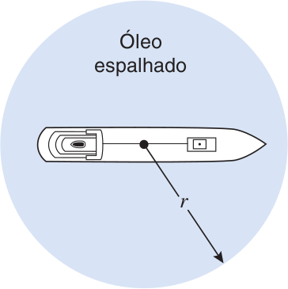

1. Com que velocidade a área do derramamento está crescendo quando seu raio for de 38.71 metros?
- **São dados \(\frac{dr}{dt} = 13.08\) e \(r_0 = 38.71\).**

### Solução

- Sabemos que o raio depende do tempo, \(r=r(t)\)
- Sabemos como calcular a área de um círculo de raio \(r\) \[A = \pi r^2\]
- Como o raio depende do tempo a área também dependerá \(A = A(t)\)
- Usando a regra da cadeia, podemos calcular a derivada da área em relação a \(t\) -\[\begin{align}\frac{dA(t)}{dt} &= \pi\frac{d}{dt}\left[r(t)^2\right]\\ &= 2\pi r \frac{dr}{dt}\end{align}\]
- Substituindo \(\frac{dr}{dt}\) e \(r_0\) dados no problema -\[\begin{align}\left.\frac{dA}{dt}\right|_{r_0} &= 2\pi r_0 \frac{dr}{dt}\\ &= 2\pi\cdot38.71\cdot 13.08\\ &\approx 3181.3451\end{align}\]

## Problema 4

## Problema 4

Um barco deixa o porto às 12 h e viaja para o sul com velocidade de 10 km/h. Também às 12 h um outro barco estava viajando na direção leste, em direção ao mesmo porto, a 15 km/h. Ele chega ao porto às 19 h.

1. Qual é a taxa de variação da distância entre eles 30 minutos após às 12 h
2. Quantas horas após as 12 h os barcos estavam mais próximos um do outro? (Não converter fração de hora para minutos)

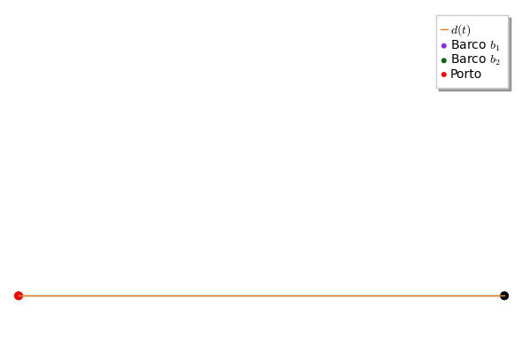